# Project: Investigate a Dataset ([TMDB-Movies Data])

- Introduction
- Data Wrangling
- Exploratory Data Analysis
- Conclusions
- Limitation

## Introduction

Dataset contains 10,866 rows, 21 columns (id,imdb_id,popularity, budget, revenue,.. ), Also, the dataset contains null_values that must be handle with them by drop or filling, and there are columns separated by a delimiter that must be separated to extract important information from them, such as a column(cast,genres)

## Questions for Analysis:

1) Movies that make profits $1Billion or more.  
2) who are top 10 cast?  
3) what are top 10 popularity movies?  
4) Movies with high and low vote_average  
5) what is the number of movies for each Genre?  
6) Movies that have revenues 10 times their budget.  
7) what is the profit in each release year?  
8) Any features dependent on each other ?  
9) Visualization between two high features

```python
import pandas as pd
import numpy as np
import matplotlib.pyplot as plt
import seaborn as sns
%matplotlib inline
```

## Data Wrangling

in this section apply preprossing to dataset to become clean and suitable format to apply analysis.

### Load Dataset

```python
# Load your data.
movie=pd.read_csv('tmdb-movies.csv')
#print out a few lines from data.
movie.head()
```

|  | id | imdb_id | popularity | budget | revenue | original_title | cast | homepage | director | tagline | ... | overview | runtime | genres | production_companies | release_date | vote_count | vote_average | release_year | budget_adj | revenue_adj |
| --- | --- | --- | --- | --- | --- | --- | --- | --- | --- | --- | --- | --- | --- | --- | --- | --- | --- | --- | --- | --- | --- |
| 0 | 135397 | tt0369610 | 32.985763 | 150000000 | 1513528810 | Jurassic World | Chris Pratt\|Bryce Dallas Howard\|Irrfan Khan\|Vi... | http://www.jurassicworld.com/ | Colin Trevorrow | The park is open. | ... | Twenty-two years after the events of Jurassic ... | 124 | Action\|Adventure\|Science Fiction\|Thriller | Universal Studios\|Amblin Entertainment\|Legenda... | 6/9/15 | 5562 | 6.5 | 2015 | 1.379999e+08 | 1.392446e+09 |
| 1 | 76341 | tt1392190 | 28.419936 | 150000000 | 378436354 | Mad Max: Fury Road | Tom Hardy\|Charlize Theron\|Hugh Keays-Byrne\|Nic... | http://www.madmaxmovie.com/ | George Miller | What a Lovely Day. | ... | An apocalyptic story set in the furthest reach... | 120 | Action\|Adventure\|Science Fiction\|Thriller | Village Roadshow Pictures\|Kennedy Miller Produ... | 5/13/15 | 6185 | 7.1 | 2015 | 1.379999e+08 | 3.481613e+08 |
| 2 | 262500 | tt2908446 | 13.112507 | 110000000 | 295238201 | Insurgent | Shailene Woodley\|Theo James\|Kate Winslet\|Ansel... | http://www.thedivergentseries.movie/#insurgent | Robert Schwentke | One Choice Can Destroy You | ... | Beatrice Prior must confront her inner demons ... | 119 | Adventure\|Science Fiction\|Thriller | Summit Entertainment\|Mandeville Films\|Red Wago... | 3/18/15 | 2480 | 6.3 | 2015 | 1.012000e+08 | 2.716190e+08 |
| 3 | 140607 | tt2488496 | 11.173104 | 200000000 | 2068178225 | Star Wars: The Force Awakens | Harrison Ford\|Mark Hamill\|Carrie Fisher\|Adam D... | http://www.starwars.com/films/star-wars-episod... | J.J. Abrams | Every generation has a story. | ... | Thirty years after defeating the Galactic Empi... | 136 | Action\|Adventure\|Science Fiction\|Fantasy | Lucasfilm\|Truenorth Productions\|Bad Robot | 12/15/15 | 5292 | 7.5 | 2015 | 1.839999e+08 | 1.902723e+09 |
| 4 | 168259 | tt2820852 | 9.335014 | 190000000 | 1506249360 | Furious 7 | Vin Diesel\|Paul Walker\|Jason Statham\|Michelle ... | http://www.furious7.com/ | James Wan | Vengeance Hits Home | ... | Deckard Shaw seeks revenge against Dominic Tor... | 137 | Action\|Crime\|Thriller | Universal Pictures\|Original Film\|Media Rights ... | 4/1/15 | 2947 | 7.3 | 2015 | 1.747999e+08 | 1.385749e+09 |

5 rows × 21 columns

##### Number of rows and columns of dataset

```python
#show shape of dataset before preprossing
movie.shape
```

```
(10866, 21)
```

#### Show Names of column and datatype for each

```python
#show some information about dataset
movie.info()
```

```
<class 'pandas.core.frame.DataFrame'>
RangeIndex: 10866 entries, 0 to 10865
Data columns (total 21 columns):
 #   Column                Non-Null Count  Dtype
---  ------                --------------  -----
 0   id                    10866 non-null  int64
 1   imdb_id               10856 non-null  object
 2   popularity            10866 non-null  float64
 3   budget                10866 non-null  int64
 4   revenue               10866 non-null  int64
 5   original_title        10866 non-null  object
 6   cast                  10790 non-null  object
 7   homepage              2936 non-null   object
 8   director              10822 non-null  object
 9   tagline               8042 non-null   object
 10  keywords              9373 non-null   object
 11  overview              10862 non-null  object
 12  runtime               10866 non-null  int64
 13  genres                10843 non-null  object
 14  production_companies  9836 non-null   object
 15  release_date          10866 non-null  object
 16  vote_count            10866 non-null  int64
 17  vote_average          10866 non-null  float64
 18  release_year          10866 non-null  int64
 19  budget_adj            10866 non-null  float64
 20  revenue_adj           10866 non-null  float64
dtypes: float64(4), int64(6), object(11)
memory usage: 1.7+ MB
```

#### Descriptive statistics

```python
# calculate to each columns (count, mean, std, min, 25%, 50%, 75%, max)
movie.describe()
```

[output not shown]

### Data Cleaning

in this section handle any missing value, drop any not used columns and convert any format not correct

#### Drop columns that not usesd for analysis

```python
#drop unused columns
unused_columns=['id','imdb_id','homepage','director','tagline','keywords','overview','production_companies','vote_count','budget_adj','revenue_adj']
movie=movie.drop(unused_columns,1)
movie.head(3)
```

|  | popularity | budget | revenue | original_title | cast | runtime | genres | release_date | vote_average | release_year |
| --- | --- | --- | --- | --- | --- | --- | --- | --- | --- | --- |
| 0 | 32.985763 | 150000000 | 1513528810 | Jurassic World | Chris Pratt\|Bryce Dallas Howard\|Irrfan Khan\|Vi... | 124 | Action\|Adventure\|Science Fiction\|Thriller | 6/9/15 | 6.5 | 2015 |
| 1 | 28.419936 | 150000000 | 378436354 | Mad Max: Fury Road | Tom Hardy\|Charlize Theron\|Hugh Keays-Byrne\|Nic... | 120 | Action\|Adventure\|Science Fiction\|Thriller | 5/13/15 | 7.1 | 2015 |
| 2 | 13.112507 | 110000000 | 295238201 | Insurgent | Shailene Woodley\|Theo James\|Kate Winslet\|Ansel... | 119 | Adventure\|Science Fiction\|Thriller | 3/18/15 | 6.3 | 2015 |

#### find all null values in dataset

```python
#show columns with null values
movie.isnull().sum()
```

```
popularity         0
budget             0
revenue            0
original_title     0
cast              76
runtime            0
genres            23
release_date       0
vote_average       0
release_year       0
dtype: int64
```

### Drop any null value

```python
#drop any null value
movie.dropna(inplace=True)
```

```python
#check that there is not any null values
movie.isnull().sum()
```

```
popularity        0
budget            0
revenue           0
original_title    0
cast              0
runtime           0
genres            0
release_date      0
vote_average      0
release_year      0
dtype: int64
```

#### Find duplicated rows in dataset

```python
#check any duplicated row
movie.duplicated().sum()
```

```
1
```

#### Drop duplicated row from dataset

```python
#drop duplicated row
movie.drop_duplicates(inplace=True)
```

```python
#show shape of data after preprossing
movie.shape
```

```
(10767, 10)
```

### Replace 0 with mean of column

```python
#replace any 0 in column budget with mean
movie['budget']=movie['budget'].replace(0,movie['budget'].mean())
```

```python
#replace any 0 in column budget with mean
movie['revenue']=movie['revenue'].replace(0,movie['revenue'].mean())
```

```python
#convert release_date from object to date
movie['release_date']=pd.to_datetime(movie['release_date'])
```

```python
#show show some information about dataset and check formate of release_date
movie.info()
```

```
<class 'pandas.core.frame.DataFrame'>
Int64Index: 10767 entries, 0 to 10865
Data columns (total 10 columns):
 #   Column          Non-Null Count  Dtype
---  ------          --------------  -----
 0   popularity      10767 non-null  float64
 1   budget          10767 non-null  float64
 2   revenue         10767 non-null  float64
 3   original_title  10767 non-null  object
 4   cast            10767 non-null  object
 5   runtime         10767 non-null  int64
 6   genres          10767 non-null  object
 7   release_date    10767 non-null  datetime64[ns]
 8   vote_average    10767 non-null  float64
 9   release_year    10767 non-null  int64
dtypes: datetime64[ns](1), float64(4), int64(2), object(3)
memory usage: 925.3+ KB
```

#### Create new column profit movie

```python
#calculate profit of each movie
movie['profit_movie']=movie['revenue']-movie['budget']
#print out a few lines from data.
movie.head(3)
```

|  | popularity | budget | revenue | original_title | cast | runtime | genres | release_date | vote_average | release_year | profit_movie |
| --- | --- | --- | --- | --- | --- | --- | --- | --- | --- | --- | --- |
| 0 | 32.985763 | 150000000.0 | 1.513529e+09 | Jurassic World | Chris Pratt\|Bryce Dallas Howard\|Irrfan Khan\|Vi... | 124 | Action\|Adventure\|Science Fiction\|Thriller | 2015-06-09 | 6.5 | 2015 | 1.363529e+09 |
| 1 | 28.419936 | 150000000.0 | 3.784364e+08 | Mad Max: Fury Road | Tom Hardy\|Charlize Theron\|Hugh Keays-Byrne\|Nic... | 120 | Action\|Adventure\|Science Fiction\|Thriller | 2015-05-13 | 7.1 | 2015 | 2.284364e+08 |
| 2 | 13.112507 | 110000000.0 | 2.952382e+08 | Insurgent | Shailene Woodley\|Theo James\|Kate Winslet\|Ansel... | 119 | Adventure\|Science Fiction\|Thriller | 2015-03-18 | 6.3 | 2015 | 1.852382e+08 |

### Function return 10 top movies

```python
#this function return top 10 movies depend on given column
def top_10_movie(column):
    top_movies = movie.sort_values(by=[column],ascending=False).head(10)
    return top_movies[['original_title',column]]
```

## Exploratory Data Analysis

### Research Question 1: Movies that make profits 1Billion or more.

```python
#find movies with profits more than one billion
movie_profit=movie[movie['profit_movie']>=1000000000]
movie_profit=movie_profit[['original_title','profit_movie']]
movie_profit
```

|  | original_title | profit_movie |
| --- | --- | --- |
| 0 | Jurassic World | 1.363529e+09 |
| 3 | Star Wars: The Force Awakens | 1.868178e+09 |
| 4 | Furious 7 | 1.316249e+09 |
| 8 | Minions | 1.082731e+09 |
| 14 | Avengers: Age of Ultron | 1.125036e+09 |
| 1386 | Avatar | 2.544506e+09 |
| 3374 | Harry Potter and the Deathly Hallows: Part 2 | 1.202818e+09 |
| 4361 | The Avengers | 1.299558e+09 |
| 4949 | The Lord of the Rings: The Return of the King | 1.024889e+09 |
| 5231 | Titanic | 1.645034e+09 |
| 5422 | Frozen | 1.124219e+09 |
| 5425 | Iron Man 3 | 1.015440e+09 |
| 8094 | The Net | 1.084280e+09 |

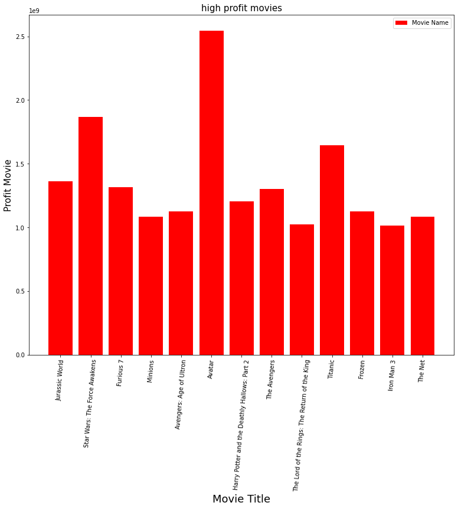

```python
#visualization Movies that make profits 1Billion or more.
fig1 = plt.figure(figsize = (10,8))
fig2 = fig1.add_axes([0,0,1,1])
fig2.bar(movie_profit['original_title'],movie_profit['profit_movie'],facecolor='r',label='Movie Name')
plt.title("high profit movies",fontsize=15)
plt.legend()
plt.xlabel('Movie Title',fontsize=18)
plt.ylabel("Profit Movie",fontsize= 15);
plt.xticks(rotation = 85)
plt.show()
```

### Research Question 2: who are top 10 cast?

```python
#separating cast column by delimiter | To return the name of all cast and store them in data_cast
data_cast= movie['cast'].str.cat(sep='|')
data_cast = pd.Series(data_cast.split('|'))
cast_count = data_cast.value_counts().head(10)
cast_count
```

```
Robert De Niro       72
Samuel L. Jackson    71
Bruce Willis         62
Nicolas Cage         61
Michael Caine        53
Robin Williams       51
John Cusack          50
John Goodman         49
Morgan Freeman       49
Liam Neeson          48
dtype: int64
```

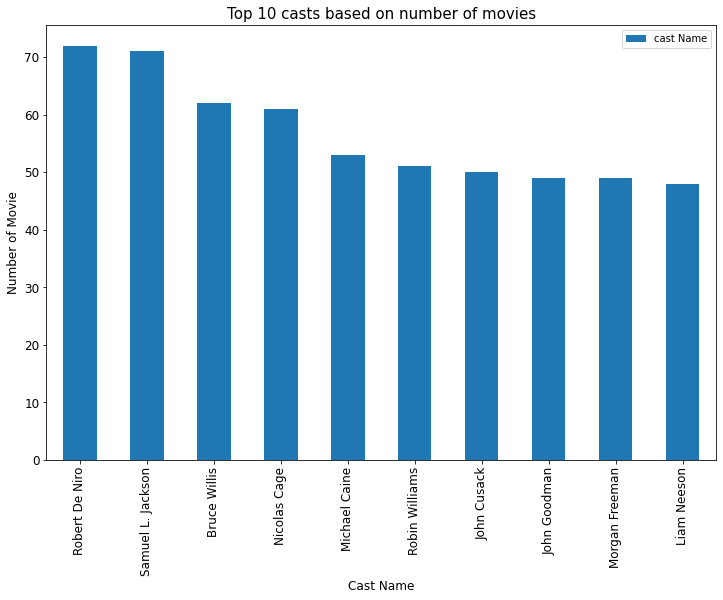

```python
#visualization Top 10 casts based on number of movies
cast_count.plot(kind= 'bar',figsize = (12,8),fontsize=12,label='cast Name')
plt.title("Top 10 casts based on number of movies",fontsize=15)
plt.legend()
plt.xlabel('Cast Name',fontsize=12)
plt.ylabel("Number of Movie",fontsize= 12);
```

### Research Question 3: what are top 10 popularity movies?

```python
#find top 10 movies based on highest popularity
popularity_movies = top_10_movie('popularity')
popularity_movies
```

|  | original_title | popularity |
| --- | --- | --- |
| 0 | Jurassic World | 32.985763 |
| 1 | Mad Max: Fury Road | 28.419936 |
| 629 | Interstellar | 24.949134 |
| 630 | Guardians of the Galaxy | 14.311205 |
| 2 | Insurgent | 13.112507 |
| 631 | Captain America: The Winter Soldier | 12.971027 |
| 1329 | Star Wars | 12.037933 |
| 632 | John Wick | 11.422751 |
| 3 | Star Wars: The Force Awakens | 11.173104 |
| 633 | The Hunger Games: Mockingjay - Part 1 | 10.739009 |

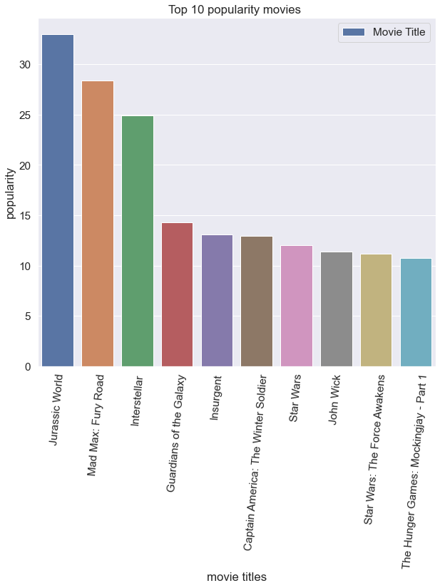

```python
#visualization Top 10 movies based on their popularity
sns.set(rc={'figure.figsize':(10,9)}, font_scale=1.4)
ax = sns.barplot(popularity_movies['original_title'],popularity_movies['popularity'],label='Movie Title')
for item in ax.get_xticklabels():
    item.set_rotation(85)
plt.legend()
ax.set(xlabel='movie titles', ylabel='popularity', title = 'Top 10 popularity movies ')
plt.show()
```

### Research Question 4:Movies with high and low vote_average

```python
#find top 10 movies with high vote average
movie_high_vote=top_10_movie('vote_average')
movie_high_vote
```

|  | original_title | vote_average |
| --- | --- | --- |
| 3894 | The Story of Film: An Odyssey | 9.2 |
| 1200 | Black Mirror: White Christmas | 8.8 |
| 6911 | Pink Floyd: Pulse | 8.7 |
| 2401 | Opeth: In Live Concert At The Royal Albert Hall | 8.6 |
| 8221 | A Personal Journey with Martin Scorsese Throug... | 8.5 |
| 3224 | John Mayer: Where the Light Is Live in Los Ang... | 8.5 |
| 3690 | The Art of Flight | 8.5 |
| 8411 | Queen - Rock Montreal | 8.5 |
| 8839 | Dave Chappelle: Killin' Them Softly | 8.5 |
| 3365 | Foo Fighters: Live at Wembley Stadium | 8.4 |

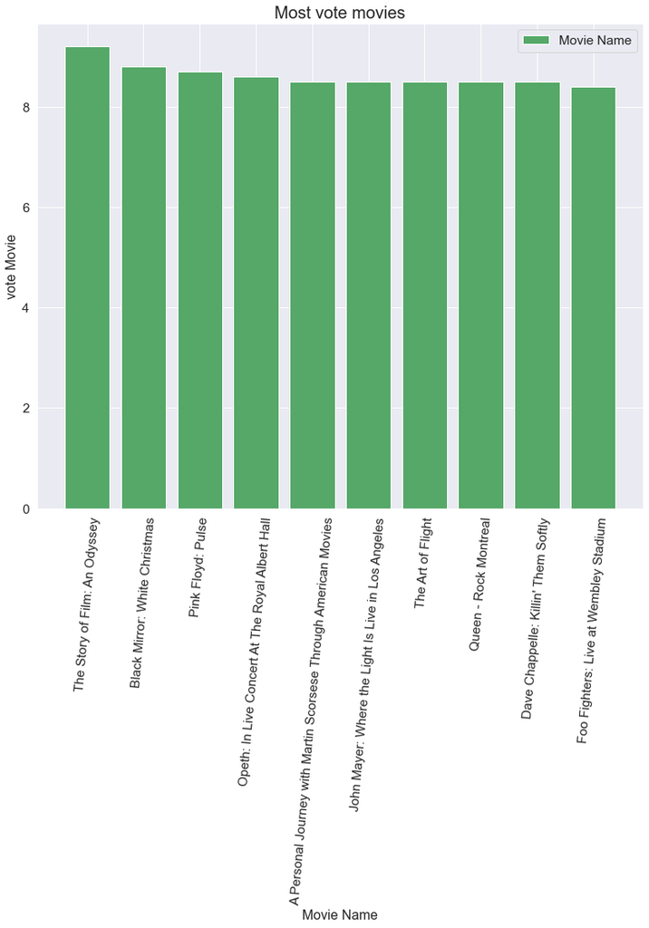

```python
#visualization top 10 movies with high vote average
fig1 = plt.figure(figsize = (10,8))
f = fig1.add_axes([0,0,1,1])
f.bar(movie_high_vote['original_title'],movie_high_vote['vote_average'],facecolor='g',label='Movie Name')
plt.title("Most vote movies",fontsize=20)
plt.legend()
plt.xlabel('Movie Name',fontsize=16)
plt.ylabel("vote Movie",fontsize= 16);
plt.xticks(rotation = 85)
plt.show()
```

```python
#find bottom 10 movies with low vote average
movie_low_vote=movie.sort_values(by=['vote_average'],ascending=True).head(10)
movie2=movie_low_vote['original_title']
movie_low_vote=movie_low_vote[['original_title','vote_average']]
movie_low_vote
```

|  | original_title | vote_average |
| --- | --- | --- |
| 10865 | Manos: The Hands of Fate | 1.5 |
| 7772 | Transmorphers | 1.5 |
| 4882 | Jurassic Shark | 2.0 |
| 3822 | Sand Sharks | 2.1 |
| 7220 | Superbabies: Baby Geniuses 2 | 2.1 |
| 2373 | Birdemic: Shock and Terror | 2.1 |
| 6077 | Atlantic Rim | 2.2 |
| 4859 | Foodfight! | 2.2 |
| 4910 | The Sleeper | 2.2 |
| 9291 | Going Overboard | 2.3 |

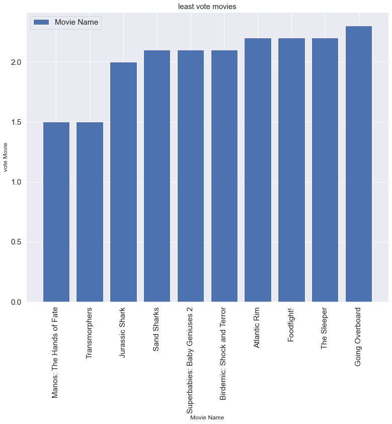

```python
#visualization bottom 10 movies with low vote average
fig1 = plt.figure(figsize = (10,8))
f = fig1.add_axes([0,0,1,1])
f.bar(movie_low_vote['original_title'],movie_low_vote['vote_average'],facecolor='b',label='Movie Name')
plt.title("least vote movies",fontsize=15)
plt.legend()
plt.xlabel('Movie Name',fontsize=12)
plt.ylabel("vote Movie",fontsize= 12);
plt.xticks(rotation = 90)
plt.show()
```

### Research Question 5: what is the number of movies for each Genre?

```python
#separating genres column by delimiter | To return all genres of movies and store them in data_genres
data_genres= movie['genres'].str.cat(sep='|')
data_genres = pd.Series(data_genres.split('|'))
data_genres_count = data_genres.value_counts()
data_genres_count
```

```
Drama              4752
Comedy             3785
Thriller           2905
Action             2381
Romance            1712
Horror             1637
Adventure          1469
Crime              1354
Science Fiction    1227
Family             1219
Fantasy             911
Mystery             809
Animation           669
Documentary         478
Music               405
History             331
War                 268
Foreign             187
TV Movie            167
Western             165
dtype: int64
```

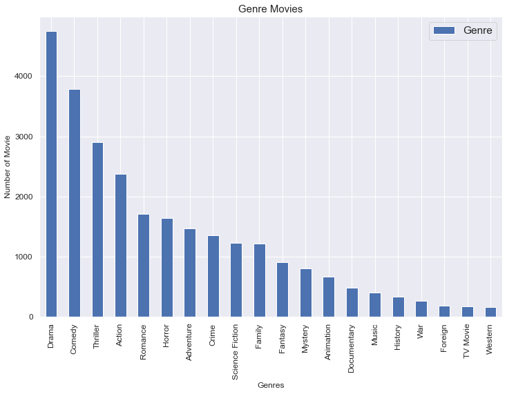

```python
#visualization all genres of movies and Number of Movie for each genre
data_genres_count.plot(kind= 'bar',figsize = (12,8),fontsize=12,label='Genre')
plt.title("Genre Movies",fontsize=15)
plt.legend()
plt.xlabel('Genres',fontsize=12)
plt.ylabel("Number of Movie",fontsize= 12);
```

### Research Question 6: Movies that have revenues 10 times their budget.

```python
# top 10 Movies that have revenues 10 times their budget.
movie_high_revenue=movie[(movie['revenue'])>=10*(movie['budget'])]
movie_high_revenue=movie_high_revenue[['original_title','revenue','budget']]
movie_high_revenue=movie_high_revenue.head(10)
movie_high_revenue
```

|  | original_title | revenue | budget |
| --- | --- | --- | --- |
| 0 | Jurassic World | 1.513529e+09 | 1.500000e+08 |
| 3 | Star Wars: The Force Awakens | 2.068178e+09 | 2.000000e+08 |
| 8 | Minions | 1.156731e+09 | 7.400000e+07 |
| 23 | Fifty Shades of Grey | 5.696515e+08 | 4.000000e+07 |
| 62 | The Witch | 4.042394e+07 | 3.500000e+06 |
| 90 | The Gift | 5.897865e+07 | 5.000000e+06 |
| 95 | Alvin and the Chipmunks: The Road Chip | 2.337556e+08 | 1.475532e+07 |
| 102 | The Boy Next Door | 5.016310e+07 | 4.000000e+06 |
| 107 | The Visit | 9.845006e+07 | 5.000000e+06 |
| 112 | No Escape | 5.441887e+07 | 5.000000e+06 |

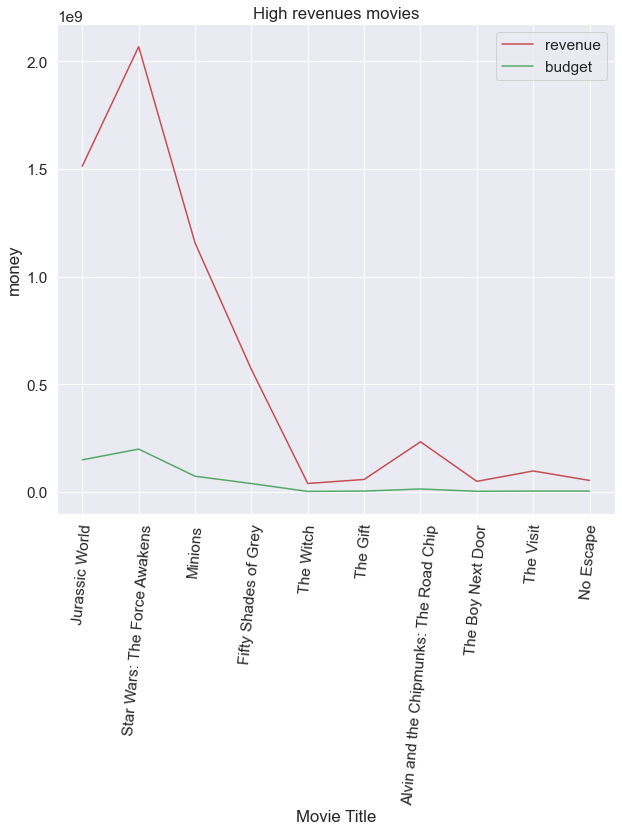

```python
# visualization top 10 Movies that have revenues 10 times their budget.
plt.plot(movie_high_revenue['original_title'], movie_high_revenue['revenue'], color='r', label='revenue')
plt.plot(movie_high_revenue['original_title'], movie_high_revenue['budget'], color='g', label='budget')
plt.xlabel("Movie Title")
plt.ylabel("money")
plt.title("High revenues movies")
plt.legend()
plt.xticks(rotation = 85)
plt.show()
```

### Research Question 7: what is the profit in each release year?

```python
#find profits that movies win each release year
movie_year = movie.groupby('release_year')['profit_movie'].sum()
movie_year
```

```
release_year
1960    7.882282e+08
1961    8.698955e+08
1962    8.195422e+08
1963    8.597258e+08
1964    1.210411e+09
1965    1.239332e+09
1966    1.173131e+09
1967    1.317218e+09
1968    8.982602e+08
1969    9.113741e+08
1970    1.134646e+09
1971    1.504373e+09
1972    1.324662e+09
1973    2.139915e+09
```

[output cut: 43 more lines]

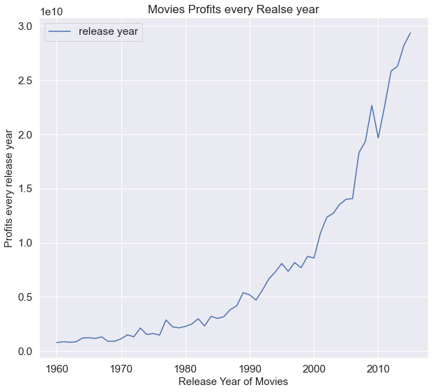

```python
# visualization Movies profits in each release year
plt.plot(movie_year,color='b', label='release year')
plt.xlabel('Release Year of Movies', fontsize = 15)
plt.ylabel('Profits every release year', fontsize = 15)
plt.title('Movies Profits every Realse year')
plt.legend()
plt.show()
```

### Research Question 8:Any features dependent on each other ?

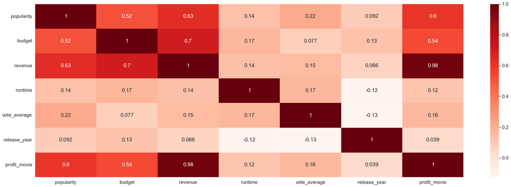

```python
#visualization correlation between each two features
features=movie.corr(method ='pearson')
plt.figure(figsize=(30,10))
sns.heatmap(features, annot=True, cmap="Reds")
plt.show()
```

#### I noticed that some feature dependent on each other such that (Revenue , profit_movie), (Revenue , Budget),(popularity , Revenue), (popularity , profit_movie), (profit_movie , Budget) and (Budget , popularity) > 0.5 and others features are weak dependent(independent) < 0.5.

#### Visualization Strong features that depend on each other

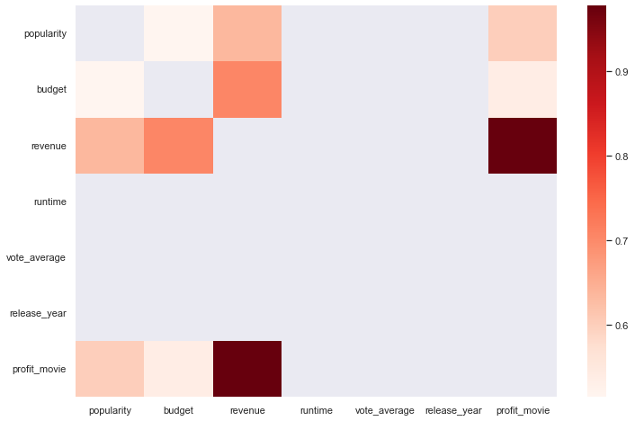

```python
#find correlation between highest two features
high_depend_features = features[(features>0.5) & (features!=1)]
plt.figure(figsize=(12,8))
sns.heatmap(high_depend_features, cmap="Reds");
```

#### (Revenue , profit_movie) are more features strong positive dependent with 98%

### Research Question 9: Visualization between two high features

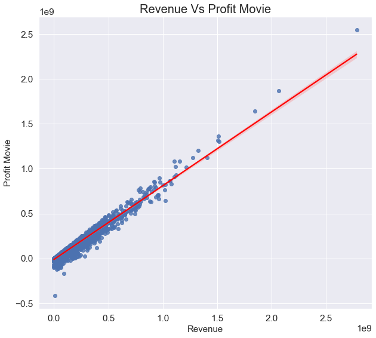

```python
#visualization highest two features(revenue,profit movie) dependent on each other
high_feature = sns.regplot(x=movie['revenue'],y=movie['profit_movie'],color='b',line_kws={"color": "red"})
high_feature.set_title("Revenue Vs Profit Movie",fontsize=20)
high_feature.set_xlabel("Revenue",fontsize=15)
high_feature.set_ylabel("Profit Movie",fontsize=15)
#setup the figure size.
sns.set(rc={'figure.figsize':(12,8)})
data_corr = movie.corr()
```

## Limitation:

1) the Budget and Revenue column do not have currency unit, It is possible that it has a different currency according to the country in which the movie was produced, as this affects the budget and revenues.  
2) There are Null values and 0 have lost some important information.  
3) Due to the presence of null values and droping them, this will certainly have an impact on the analysis process.  
4) The genre column had to be separated because the result took a lot of time, so it was necessary to separate and clean it before the analysis.